# ExtraaLearn Project

## EDA

- It is a good idea to explore the data once again after manipulating it.

#### Univariate Analysis

##### Plotting the Distribution of Continuous Variables

```python
# Define hist_box() function to view both a histogram and boxplot in the same visual

def hist_box(df, col):
  f, (ax_box, ax_hist) = plt.subplots(2, sharex=True, gridspec_kw={'height_ratios':(0.15,.850)}, figsize=(12,6))
  # Add a graph in each part
  sns.boxplot(data = df, x=col, ax = ax_box, showmeans=True, color = 'mintcream')
  sns.histplot(data = df, x=col, kde=True, ax=ax_hist)
  ax_hist.axvline(df[col].mean(), color = 'green', linestyle = '--')
  ax_hist.axvline(df[col].median(), color = 'black', linestyle = "-")

  plt.show()
```

###### `age`

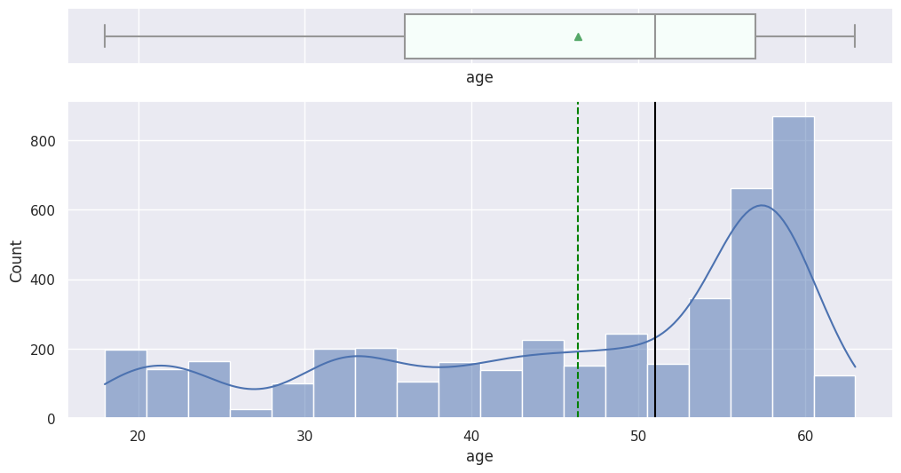

```python
hist_box(df,'age')
```

- The distribution of the age data shows the left skew that was expected with a mode in the high fifties. There seem to be some small modes especially around the beginning of decades, which can indicate people's desire to make life changes or upskilling when entering new life stages.
- It will be interesting to understand in the bivariate analysis how age plays a role in conversion to see if the right demographic is being targeted with current marketing campaigns given that there is only a 30% conversion at the moment.

###### `website_visits`

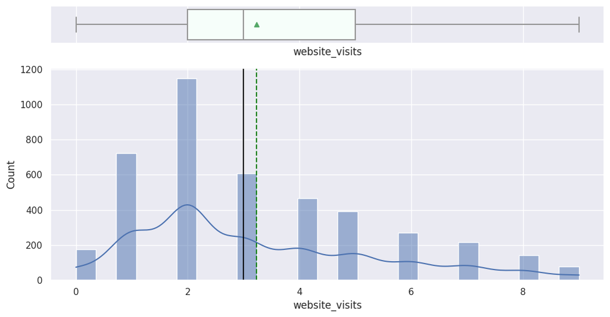

```python
hist_box(df,'website_visits')
```

```python
web_visit_outliers = df['website_visits'] > 9
web_visit_outliers.sum()
```

```
0
```

```python
web_outliers = df['website_visits'] > 15
web_outliers.sum()
```

```
0
```

###### `time_spent_on_website`

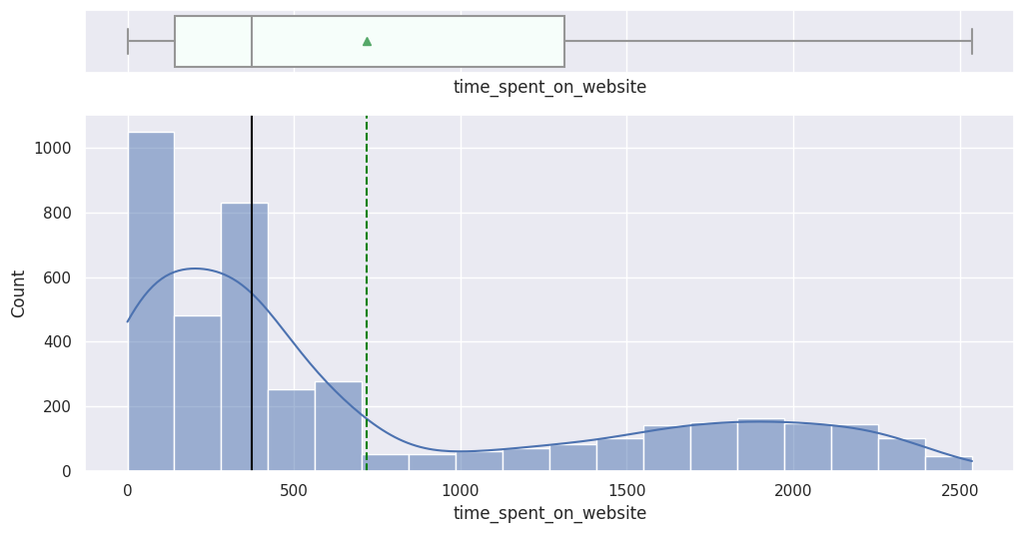

```python
hist_box(df,'time_spent_on_website')
```

- The data appears to have a bi-modal tendency with a clear mode below the median
- As we saw in our original outlier calculations, the graph does not detect any clear outliers in this feature due to the large standard deviation

###### `page_views_per_visit`

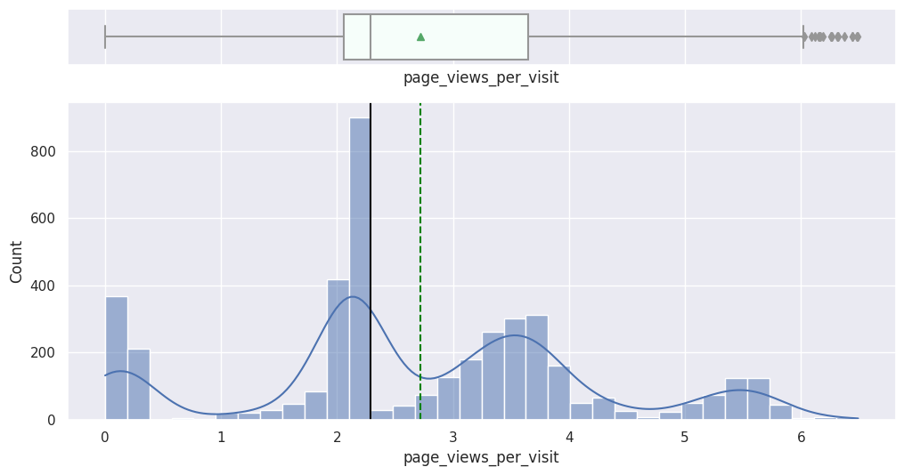

```python
hist_box(df,'page_views_per_visit')
```

```python
page_views_outliers = df['page_views_per_visit'] > 6.5
page_views_outliers.sum()
```

```
0
```

```python
page_outliers = df['page_views_per_visit'] > 10
web_outliers.sum()
page_outliers.sum()
```

```
0
```